# Análisis del dataset de *Titulos de Nentflix:* datos, limpieza y modelos en Python

Este notebook usa el dataset clásico del **Netflix** para practicar un flujo completo de trabajo con datos:

- cargar y entender una tabla,
- detectar problemas de calidad,
- limpiar valores faltantes y tipos incorrectos,
- crear variables nuevas a partir de la información existente,
- explorar patrones con tablas y gráficas,
- construir un modelo logístico para estimar probabilidad de que un nuevo titulo sea de una pelicula.

La idea no es predecir con precisión perfecta, sino **aprender a manejar información real**: incompleta, desordenada y con decisiones de limpieza que afectan el análisis.

```python
!pip install pandas numpy statsmodels scikit-learn
import pandas as pd
import numpy as np
import matplotlib.pyplot as plt
import statsmodels.api as sm
import statsmodels.formula.api as smf
from sklearn.model_selection import train_test_split
from sklearn.metrics import accuracy_score, confusion_matrix, classification_report
plt.rcParams["figure.figsize"] = (8, 5)
plt.rcParams["axes.grid"] = True
```

## 1. Carga de datos

Cada fila representa una pelicula o una serie que se ofrece en el catalogo de Netflix. Las columnas más importantes son:

- `Type`: Esquema de contenido (`Movie`) o (`TV Show`).
- `Title`: Nombre de la pelicula o serie (`Titulos varios`).
- `Director`: Nombre del director de la pelicula o serie.
- `Cast`: Nombre de los actores principales.
- `Country`: Pais de origen.
- `date_added`: Fecha en la que se agrego a la plataforma.
- `release_year`: Año de estreno.
- `Rating`: Certificacion de contenido (`G`, `PG`, `PG-13`,`R`) etc ...
- `Duration`: Tiempo estimado en minutos o en temporadas.
- `Listed_in`: categoria en la cual se lista el contenido.
- `Description`: Breve reseña de la historia de la pelicula o Serie.

Usaremos un CSV local en `netflix_titles.csv`.

```python
from pathlib import Path

REPO_ROOT = Path.cwd() if (Path.cwd() / "data").exists() else Path.cwd().parent
DATA_PATH = REPO_ROOT / "data" / "netflix_titles.csv"


if DATA_PATH.exists():
    df_original = pd.read_csv(DATA_PATH)
    print("Filas y columnas originales:", df_original.shape)
    df_original.head()
else:
   print("El archivo no existe en el disco")
```

```
Filas y columnas originales: (8807, 12)
```

## 2. Revisión inicial de los datos

Antes de limpiar, siempre conviene responder tres preguntas básicas:

1. ¿Qué columnas tengo?
2. ¿Qué tipo de dato tiene cada una?
3. ¿Hay valores faltantes o algo que no cuadre?

En este dataset ya podemos anticipar un problema típico: **muchas columnas tienen nulos**,especialmente `Director` y `Country`.

```python
print("Columnas disponibles:")
print(df_original.columns.tolist())

print("\nTipos de datos:")
display(df_original.dtypes.to_frame("tipo"))

print("\nValores faltantes por columna:")
missing = df_original.isnull().sum().sort_values(ascending=False)
missing_pct = (missing / len(df_original) * 100).round(1)
display(pd.DataFrame({"faltantes": missing, "porcentaje": missing_pct}))

print("\nResumen numérico:")
display(df_original.describe().T)

print("\nCantidad de Series y Peliculas:")
display(df_original["type"].value_counts().rename({0: "Movie", 1: "TV Show"}))
```

```
Columnas disponibles:
['show_id', 'type', 'title', 'director', 'cast', 'country', 'date_added', 'release_year', 'rating', 'duration', 'listed_in', 'description']

Tipos de datos:
```

|  | tipo |
| --- | --- |
| show_id | str |
| type | str |
| title | str |
| director | str |
| cast | str |
| country | str |
| date_added | str |
| release_year | int64 |
| rating | str |
| duration | str |
| listed_in | str |
| description | str |

```
Valores faltantes por columna:
```

|  | faltantes | porcentaje |
| --- | --- | --- |
| director | 2634 | 29.9 |
| country | 831 | 9.4 |
| cast | 825 | 9.4 |
| date_added | 10 | 0.1 |
| rating | 4 | 0.0 |
| duration | 3 | 0.0 |
| show_id | 0 | 0.0 |
| type | 0 | 0.0 |
| title | 0 | 0.0 |
| release_year | 0 | 0.0 |
| listed_in | 0 | 0.0 |
| description | 0 | 0.0 |

```
Resumen numérico:
```

|  | count | mean | std | min | 25% | 50% | 75% | max |
| --- | --- | --- | --- | --- | --- | --- | --- | --- |
| release_year | 8807.0 | 2014.180198 | 8.819312 | 1925.0 | 2013.0 | 2017.0 | 2019.0 | 2021.0 |

```
Cantidad de Series y Peliculas:
```

```
type
Movie      6131
TV Show    2676
Name: count, dtype: int64
```

## 3. Auditoría de calidad

La limpieza empieza con un diagnóstico. Revisamos:

1. **Duplicados**: filas repetidas que podrían inflar conteos.
2. **Valores imposibles**: edades negativas, tarifas negativas, clases fuera de rango.
3. **Cardinalidad**: cuántos valores distintos tiene cada columna categórica.
4. **Consistencia**: si los tipos de datos coinciden con el significado de la columna.

Esta auditoría nos dice *qué* hay que corregir y *por qué*.

```python
print("--- Auditoría de calidad ---")

duplicados = df_original.duplicated().sum()
print("Filas duplicadas:", duplicados)

print("\nAño de lanzamiento negativos:", (df_original["release_year"] < 0).sum())

print("Tipo de contenido invalido:", (~df_original["type"].isin(["Movie", "TV Show"])).sum())

print("\nValores únicos por columna:")
for col in df_original.columns:
    print(f"- {col}: {df_original[col].nunique()}")

print("\nDistribución de Peliculas por su rating:")
display(df_original["rating"].value_counts())

print("\nDistribución por el año de lazamiento:")
display(df_original["release_year"].value_counts(dropna=False))
```

```
--- Auditoría de calidad ---
Filas duplicadas: 0

Año de lanzamiento negativos: 0
Tipo de contenido invalido: 0

Valores únicos por columna:
- show_id: 8807
- type: 2
- title: 8807
- director: 4528
- cast: 7692
- country: 748
- date_added: 1767
- release_year: 74
- rating: 17
- duration: 220
- listed_in: 514
- description: 8775

Distribución de Peliculas por su rating:
```

```
rating
TV-MA       3207
TV-14       2160
TV-PG        863
R            799
PG-13        490
TV-Y7        334
TV-Y         307
PG           287
TV-G         220
NR            80
G             41
TV-Y7-FV       6
NC-17          3
UR             3
74 min         1
84 min         1
66 min         1
Name: count, dtype: int64
```

```
Distribución por el año de lazamiento:
```

```
release_year
2018    1147
2017    1032
2019    1030
2020     953
2016     902
        ...
1961       1
1959       1
1925       1
1966       1
1947       1
Name: count, Length: 74, dtype: int64
```

## 4. Limpieza de datos

Vamos a limpiar paso a paso y documentar cada decisión.

### Decisiones de limpieza

1. **`Director`**: faltan 2634 valores. Los reemplazamos por la la palabra(`Desconocido`).
2. **`Country`**: faltan 831 valores. En lugar de borrar esas filas, Los reemplazamos por la la palabra(`Desconocido`).
3. **`Cast`**: faltan 825 valores. En lugar de borrar esas filas, Los reemplazamos por la la palabra(`Desconocido`).
4. **`Date_added`**: faltan 10 valores. por lo cúal seran eliminados
5. **`Rating`**: faltan 4 valores. por lo cúal voy a buscar y agregar manualmente el valor
6. **`Duration`**: faltan 3 valores. por lo cúal seran eliminados.

```python
print("--- Iniciando limpieza de datos ---")

df = df_original.copy()
filas_inicio = len(df)

# 1) Director: faltan 2634 valores. Los reemplazamos por la la palabra(Desconocido).
df["director"] = df["director"].fillna("Desconocido")

# 2) Country: faltan 831 valores. En lugar de borrar esas filas, Los reemplazamos por la la palabra(Desconocido).
df["country"] = df["country"].fillna("Desconocido")

# 3) Cast: faltan 825 valores. En lugar de borrar esas filas, Los reemplazamos por la la palabra(Desconocido).
df["cast"] = df["cast"].fillna("Desconocido")

# 4) date_added: faltan 10 valores. por lo cúal seran eliminados
df = df.dropna(subset=["date_added"])

# 5) Encontrar los registros que no tienen rating
display(df[df["rating"].isnull()])

#Asignar el raiting con base a su titulo
df.loc[df["title"] == "13TH: A Conversation with Oprah Winfrey & Ava DuVernay", "rating"] = "TV-14"

df.loc[df["title"] == "Gargantia on the Verdurous Planet", "rating"] = "TV-14"

df.loc[df["title"] == "Little Lunch", "rating"] = "TV-G"

df.loc[df["title"] == "My Honor Was Loyalty", "rating"] = "TV-MA"

#Verificar que no existan valores faltantes
print("Ratings faltantes:", df["rating"].isnull().sum())

# 6) duration: faltan 3 valores. por lo cúal seran eliminados
df = df.dropna(subset=["duration"])

#Verificar los valores faltantes por columna
print("\nValores faltantes por columna despues de realizar la limpieza:")
missing = df.isnull().sum().sort_values(ascending=False)
missing_pct = (missing / len(df) * 100).round(1)
display(pd.DataFrame({"faltantes": missing, "porcentaje": missing_pct}))
```

```
--- Iniciando limpieza de datos ---
```

|  | show_id | type | title | director | cast | country | date_added | release_year | rating | duration | listed_in | description |
| --- | --- | --- | --- | --- | --- | --- | --- | --- | --- | --- | --- | --- |
| 5989 | s5990 | Movie | 13TH: A Conversation with Oprah Winfrey & Ava ... | Desconocido | Oprah Winfrey, Ava DuVernay | Desconocido | January 26, 2017 | 2017 | NaN | 37 min | Movies | Oprah Winfrey sits down with director Ava DuVe... |
| 6827 | s6828 | TV Show | Gargantia on the Verdurous Planet | Desconocido | Kaito Ishikawa, Hisako Kanemoto, Ai Kayano, Ka... | Japan | December 1, 2016 | 2013 | NaN | 1 Season | Anime Series, International TV Shows | After falling through a wormhole, a space-dwel... |
| 7312 | s7313 | TV Show | Little Lunch | Desconocido | Flynn Curry, Olivia Deeble, Madison Lu, Oisín ... | Australia | February 1, 2018 | 2015 | NaN | 1 Season | Kids' TV, TV Comedies | Adopting a child's perspective, this show take... |
| 7537 | s7538 | Movie | My Honor Was Loyalty | Alessandro Pepe | Leone Frisa, Paolo Vaccarino, Francesco Miglio... | Italy | March 1, 2017 | 2015 | NaN | 115 min | Dramas | Amid the chaos and horror of World War II, a c... |

```
Ratings faltantes: 0

Valores faltantes por columna despues de realizar la limpieza:
```

|  | faltantes | porcentaje |
| --- | --- | --- |
| show_id | 0 | 0.0 |
| type | 0 | 0.0 |
| title | 0 | 0.0 |
| director | 0 | 0.0 |
| cast | 0 | 0.0 |
| country | 0 | 0.0 |
| date_added | 0 | 0.0 |
| release_year | 0 | 0.0 |
| rating | 0 | 0.0 |
| duration | 0 | 0.0 |
| listed_in | 0 | 0.0 |
| description | 0 | 0.0 |

## 5. Creación de variables nuevas

Muchas veces la información útil no viene lista en una sola columna. Hay que **construirla**.

Crearemos:

- `content_age`: antiguedad del contenido (`2026 - release_year`).
- `decada`: decada de lazamiento , `1980s`,`1990s`,`2000s`, `2010s`,`2020s`
- `month_added`: mes en el que el contenido fue agregado.

Estas variables ayudan a responder preguntas como:

- ¿Netflix agrega principalmente contenido reciente o antiguo?
- ¿Qué décadas tienen más contenido disponible?
- ¿En qué meses Netflix agrega más títulos a su catálogo?
- ¿Cuál es la antigüedad promedio del contenido disponible?

```python
# Antigüedad del contenido.
df["content_age"] = 2026 - df["release_year"]

# Década de lanzamiento.
df["decade"] = (df["release_year"] // 10) * 10
df["decade"] = df["decade"].astype(str) + "s"

# Convertir la fecha a formato datetime.
df["date_added"] = df["date_added"].str.strip()
df["date_added"] = pd.to_datetime(df["date_added"])

# Mes en el que el contenido fue agregado.
df["month_added"] = df["date_added"].dt.month_name()

new_columns = [
    "content_age",
    "decade",
    "month_added"
]

display(df[new_columns].head(10))


print("\nContenido por década:")
display(df["decade"].value_counts().sort_index())

print("\nContenido agregado por mes:")
display(df["month_added"].value_counts())

print("\nAntigüedad del contenido:")
display(df["content_age"].describe())
```

|  | content_age | decade | month_added |
| --- | --- | --- | --- |
| 0 | 6 | 2020s | September |
| 1 | 5 | 2020s | September |
| 2 | 5 | 2020s | September |
| 3 | 5 | 2020s | September |
| 4 | 5 | 2020s | September |
| 5 | 5 | 2020s | September |
| 6 | 5 | 2020s | September |
| 7 | 33 | 1990s | September |
| 8 | 5 | 2020s | September |
| 9 | 5 | 2020s | September |

```
Contenido por década:
```

```
decade
1920s       1
1940s      15
1950s      11
1960s      25
1970s      70
1980s     129
1990s     274
2000s     807
2010s    5917
2020s    1545
Name: count, dtype: int64
```

```
Contenido agregado por mes:
```

```
month_added
July         827
December     813
September    769
April        763
October      760
August       754
March        742
January      738
June         728
November     705
May          632
February     563
Name: count, dtype: int64
```

```
Antigüedad del contenido:
```

```
count    8794.000000
mean       11.816466
std         8.823527
min         5.000000
25%         7.000000
50%         9.000000
75%        13.000000
max       101.000000
Name: content_age, dtype: float64
```

## 6. Visualizaciones exploratorias

Las tablas resumen números, pero las gráficas ayudan a **ver patrones** más rápido.

Observa especialmente:

- la diferencia de lanzamiento de peliculas y series por paises,
- cómo se comporta netflix al agregar nuevos titulos a lo largo de un año,
- la cantidad de peliculas y series en funcion de la decada,

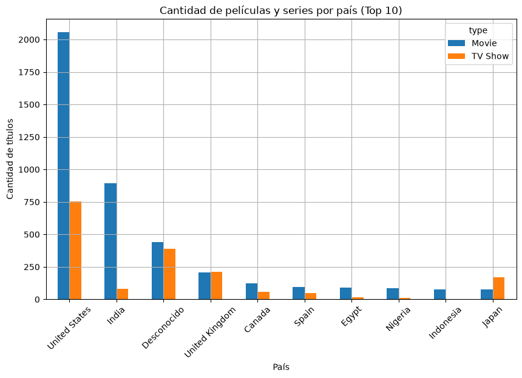

```python
# Películas y series por país (Top 10)

country_type = (
    df.groupby(["country", "type"])
      .size()
      .unstack(fill_value=0)
      .sort_values(by="Movie", ascending=False)
      .head(10)
)

country_type.plot(
    kind="bar",
    figsize=(10,6),
    title="Cantidad de películas y series por país (Top 10)"
)

plt.ylabel("Cantidad de títulos")
plt.xlabel("País")
plt.xticks(rotation=45)
plt.show()
```

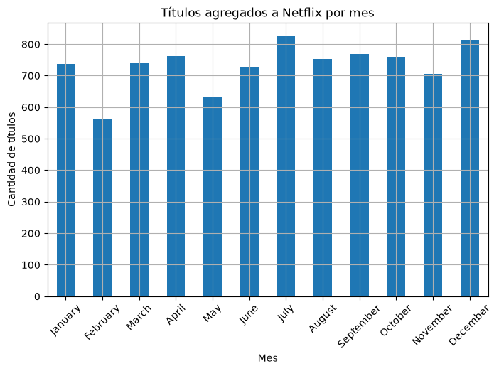

```python
# Cantidad de títulos agregados por mes

month_order = [
    "January", "February", "March", "April",
    "May", "June", "July", "August",
    "September", "October", "November", "December"
]

titles_month = (
    df["month_added"]
    .value_counts()
    .reindex(month_order)
)

titles_month.plot(
    kind="bar",
    title="Títulos agregados a Netflix por mes"
)

plt.ylabel("Cantidad de títulos")
plt.xlabel("Mes")
plt.xticks(rotation=45)
plt.show()
```

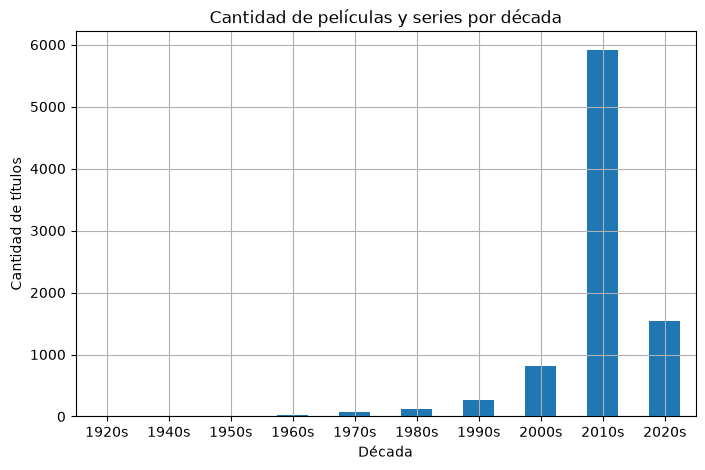

```python
# Cantidad de títulos por década

titles_decade = (
    df["decade"]
    .value_counts()
    .sort_index()
)

titles_decade.plot(
    kind="bar",
    title="Cantidad de películas y series por década"
)

plt.ylabel("Cantidad de títulos")
plt.xlabel("Década")
plt.xticks(rotation=0)
plt.show()
```

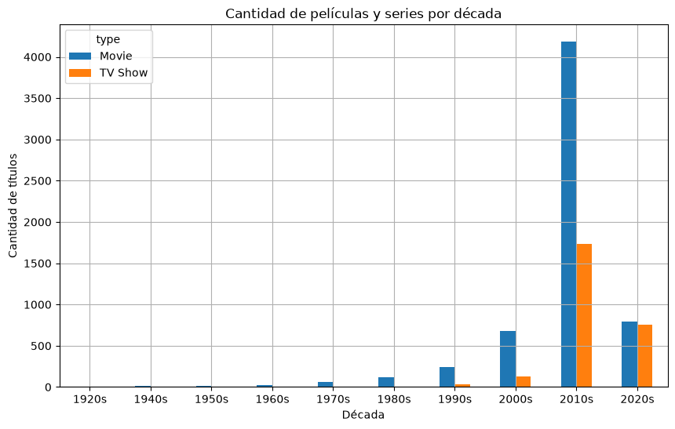

```python
# Películas y series por década

decade_type = (
    df.groupby(["decade", "type"])
      .size()
      .unstack(fill_value=0)
)

decade_type.plot(
    kind="bar",
    figsize=(10,6),
    title="Cantidad de películas y series por década"
)

plt.ylabel("Cantidad de títulos")
plt.xlabel("Década")
plt.xticks(rotation=0)
plt.show()
```

### Cómo leer estas visualizaciones

- **Country:** En la grafica se puede ver que El pais de origen de contenido para series y peliculas es Estados unidos
- **Month_added:** Se puede ver que en julio y diciembre existe un mayor numero de titulos agregados por la plataforma aunque en todo el año se mantiene uniforme
- **Decade:** La gran mayoria de las peliculas y series que se encuentran disponibles en netflix son de la decada de 2010

## 7. Regresión logística para Serie o pelicula

Después de limpiar y crear variables, podemos modelar la pregunta central:

> ¿El año de lanzamiento influye en la probabilidad de que un contenido sea una película o una serie?

Usamos **regresión logística** porque `type` se puede modelar como una variable binaria (`0: TV Show` o `1: Movie`).

La fórmula con `statsmodels` nos permite interpretar coeficientes.

```python
print("--- Regresión logística---")

df["type"] = df["type"].map({
    "Movie": 1,
    "TV Show": 0
})

modelo_df = df[[
    "type", "release_year"
]].copy()

formula = "type ~ release_year "
modelo_logit = smf.logit(formula, data=modelo_df).fit(disp=0)

display(modelo_logit.summary().tables[1])
print("Pseudo R-cuadrado:", round(modelo_logit.prsquared, 4))
```

[output not shown]

|  | coef | std err | z | P>\|z\| | [0.025 | 0.975] |
| --- | --- | --- | --- | --- | --- | --- |
| Intercept | 162.6424 | 9.899 | 16.431 | 0.000 | 143.242 | 182.043 |
| release_year | -0.0803 | 0.005 | -16.354 | 0.000 | -0.090 | -0.071 |

```
Pseudo R-cuadrado: 0.0381
```

### Interpretación del modelo logístico

En regresión logística, un coeficiente positivo indica que **aumenta la probabilidad** del evento (El contenido sea pelicula). Un coeficiente negativo indica lo contrario (el contenido es serie).

El **Pseudo R-cuadrado** da una idea general del ajuste, pero no se interpreta igual que en regresión lineal.

## 8. Evaluación con train/test split

Para revisar si el modelo generaliza, separamos datos de entrenamiento y prueba.

Esto es importante en cualquier curso de datos: **no basta con ajustar bien en la misma muestra**; hay que probar con datos que el modelo no vio durante el entrenamiento.

```python
# Preparar matriz para sklearn usando las mismas variables.
X = pd.get_dummies(modelo_df.drop(columns=["type"]), drop_first=True)
y = modelo_df["type"]

X_train, X_test, y_train, y_test = train_test_split(
    X, y, test_size=0.2, random_state=42, stratify=y
)

# Ajustar con statsmodels en entrenamiento.
train_data = X_train.copy()
train_data["type"] = y_train.values

formula_cols = "type ~ " + " + ".join([c for c in train_data.columns if c != "type"])
modelo_train = smf.logit(formula_cols, data=train_data).fit(disp=0)

# Predecir probabilidades y clases en prueba.
probs = modelo_train.predict(X_test)
preds = (probs >= 0.5).astype(int)

print("Exactitud en prueba:", round(accuracy_score(y_test, preds), 4))
print("\nMatriz de confusión:")
display(pd.DataFrame(
    confusion_matrix(y_test, preds),
    index=["Real: No", "Real: Sí"],
    columns=["Pred: No", "Pred: Sí"]
))

print("\nReporte de clasificación:")
print(classification_report(y_test, preds, target_names=["TV Show", "Movie"]))
```

```
Exactitud en prueba: 0.697

Matriz de confusión:
```

|  | Pred: No | Pred: Sí |
| --- | --- | --- |
| Real: No | 0 | 533 |
| Real: Sí | 0 | 1226 |

```
Reporte de clasificación:
              precision    recall  f1-score   support

     TV Show       0.00      0.00      0.00       533
       Movie       0.70      1.00      0.82      1226

    accuracy                           0.70      1759
   macro avg       0.35      0.50      0.41      1759
weighted avg       0.49      0.70      0.57      1759
```

## 9. Resumen final: qué aprendimos sobre manejo de datos

### Mensajes clave para el curso

- Los datos rara vez llegan listos: **la limpieza es parte del análisis**, no un paso menor.
- Cada decisión de imputación cambia resultados: conviene **documentar y justificar**.
- Las visualizaciones ayudan a detectar sesgos y relaciones antes de modelar.
- Un modelo puede ajustar bien, pero hay que interpretar con contexto histórico y ético.

La parte más importante no es solo correr el modelo, sino **saber leer la historia que cuentan los datos**.